# Análise de dados com Python

## Esse treinamento apresenta algumas das principais ferramentas disponíveis na linguagem python para análise de dados. Abordaremos os seguintes tópicos:

### 1 - Compreensão dos dados

### 2 - Análise estatística dos dados

### 3 - Operações em DataFrames

### 4 - Análises de negócio

### 5 - SVM e RF como classificadores para o problema da predição

##### Fonte: IBGE / DETRAN

## 1 - Compreensão dos dados

```python
import pandas as pd
df_frota = pd.read_csv('frotarj.csv',sep=';')
```

```python
df_frota
```

|  | UF | MUNICIPIO | TOTAL | AUTOMOVEL | BONDE | CAMINHAO | CAMINHAO TRATOR | CAMINHONETE | CAMIONETA | CHASSI PLATAF | ... | ONIBUS | QUADRICICLO | REBOQUE | SEMI-REBOQUE | SIDE-CAR | OUTROS | TRATOR ESTEI | TRATOR RODAS | TRICICLO | UTILITARIO |
| --- | --- | --- | --- | --- | --- | --- | --- | --- | --- | --- | --- | --- | --- | --- | --- | --- | --- | --- | --- | --- | --- |
| 0 | RJ | ANGRA DOS REIS | 59298 | 34818 | 0 | 1276 | 93 | 3970 | 2039 | 0 | ... | 374 | 0 | 557 | 108 | 3 | 7 | 0 | 4 | 45 | 526 |
| 1 | RJ | APERIBE | 6343 | 2351 | 0 | 145 | 2 | 277 | 77 | 0 | ... | 14 | 0 | 59 | 5 | 1 | 0 | 0 | 0 | 3 | 2 |
| 2 | RJ | ARARUAMA | 63745 | 38878 | 0 | 1911 | 151 | 3638 | 2180 | 0 | ... | 182 | 0 | 1163 | 234 | 5 | 12 | 0 | 1 | 23 | 362 |
| 3 | RJ | AREAL | 5908 | 3244 | 0 | 193 | 29 | 405 | 170 | 0 | ... | 44 | 0 | 77 | 27 | 0 | 0 | 0 | 0 | 0 | 29 |
| 4 | RJ | ARMACAO DE BUZIOS | 20803 | 11447 | 0 | 372 | 12 | 1475 | 946 | 0 | ... | 73 | 0 | 355 | 17 | 0 | 0 | 0 | 4 | 12 | 390 |
| 5 | RJ | ARRAIAL DO CABO | 11694 | 7325 | 0 | 204 | 12 | 765 | 510 | 0 | ... | 17 | 0 | 221 | 11 | 0 | 2 | 0 | 1 | 3 | 106 |
| 6 | RJ | BARRA DO PIRAI | 35609 | 23227 | 0 | 1406 | 156 | 2112 | 1679 | 0 | ... | 305 | 0 | 397 | 151 | 1 | 4 | 0 | 6 | 15 | 184 |
| 7 | RJ | BARRA MANSA | 72955 | 50961 | 0 | 1972 | 655 | 4631 | 2404 | 0 | ... | 653 | 0 | 724 | 698 | 1 | 4 | 0 | 27 | 20 | 390 |
| 8 | RJ | BELFORD ROXO | 112060 | 75236 | 0 | 2092 | 181 | 4933 | 4517 | 0 | ... | 799 | 0 | 633 | 161 | 1 | 4 | 0 | 30 | 45 | 196 |
| 9 | RJ | BOM JARDIM | 13756 | 7610 | 0 | 690 | 180 | 1065 | 450 | 0 | ... | 57 | 0 | 195 | 176 | 5 | 2 | 0 | 1 | 7 | 84 |
| 10 | RJ | BOM JESUS DO ITABAPOANA | 13260 | 5755 | 0 | 304 | 28 | 589 | 251 | 0 | ... | 65 | 0 | 103 | 26 | 6 | 2 | 0 | 1 | 8 | 13 |
| 11 | RJ | CABO FRIO | 106811 | 64465 | 0 | 3108 | 225 | 6786 | 4785 | 0 | ... | 455 | 0 | 1713 | 346 | 5 | 21 | 0 | 6 | 41 | 789 |
| 12 | RJ | CACHOEIRAS DE MACACU | 24741 | 13968 | 0 | 984 | 67 | 1648 | 898 | 0 | ... | 57 | 0 | 385 | 53 | 0 | 4 | 0 | 0 | 8 | 125 |
| 13 | RJ | CAMBUCI | 5398 | 2001 | 0 | 134 | 3 | 267 | 71 | 0 | ... | 33 | 0 | 70 | 7 | 0 | 1 | 0 | 0 | 3 | 10 |
| 14 | RJ | CAMPOS DOS GOYTACAZES | 219673 | 130586 | 0 | 6863 | 725 | 12071 | 5955 | 0 | ... | 1437 | 0 | 5991 | 1097 | 16 | 11 | 0 | 41 | 44 | 989 |
| 15 | RJ | CANTAGALO | 7817 | 4472 | 0 | 221 | 13 | 566 | 213 | 0 | ... | 48 | 0 | 131 | 36 | 7 | 1 | 0 | 6 | 2 | 28 |
| 16 | RJ | CARAPEBUS | 4941 | 2558 | 0 | 150 | 7 | 294 | 157 | 0 | ... | 27 | 0 | 140 | 10 | 0 | 0 | 0 | 0 | 0 | 14 |
| 17 | RJ | CARDOSO MOREIRA | 4626 | 2032 | 0 | 176 | 22 | 264 | 107 | 0 | ... | 61 | 0 | 104 | 26 | 0 | 1 | 0 | 2 | 2 | 7 |
| 18 | RJ | CARMO | 5420 | 3175 | 0 | 158 | 8 | 465 | 118 | 0 | ... | 19 | 0 | 51 | 3 | 0 | 1 | 0 | 0 | 1 | 13 |
| 19 | RJ | CASIMIRO DE ABREU | 16219 | 9047 | 0 | 651 | 73 | 1162 | 598 | 0 | ... | 32 | 0 | 479 | 92 | 3 | 0 | 0 | 1 | 12 | 81 |
| 20 | RJ | COMENDADOR LEVY GASPARIAN | 2997 | 1618 | 0 | 164 | 10 | 175 | 93 | 0 | ... | 21 | 0 | 44 | 6 | 0 | 0 | 0 | 0 | 1 | 16 |
| 21 | RJ | CONCEICAO DE MACABU | 9581 | 4622 | 0 | 194 | 6 | 551 | 176 | 0 | ... | 58 | 0 | 233 | 6 | 0 | 0 | 0 | 1 | 3 | 32 |
| 22 | RJ | CORDEIRO | 10357 | 6639 | 0 | 288 | 21 | 652 | 306 | 0 | ... | 57 | 0 | 163 | 17 | 8 | 0 | 0 | 2 | 4 | 81 |
| 23 | RJ | DUAS BARRAS | 4290 | 2509 | 0 | 156 | 14 | 350 | 130 | 0 | ... | 10 | 0 | 68 | 17 | 1 | 0 | 0 | 0 | 0 | 20 |
| 24 | RJ | DUQUE DE CAXIAS | 276685 | 181038 | 0 | 9673 | 2286 | 15608 | 10897 | 1 | ... | 3893 | 0 | 3080 | 3450 | 7 | 19 | 0 | 44 | 207 | 794 |
| 25 | RJ | ENGENHEIRO PAULO DE FRONTIN | 5242 | 3249 | 0 | 133 | 6 | 261 | 206 | 0 | ... | 18 | 0 | 51 | 10 | 0 | 0 | 0 | 0 | 2 | 12 |
| 26 | RJ | GUAPIMIRIM | 16614 | 9506 | 0 | 461 | 40 | 1037 | 583 | 0 | ... | 55 | 0 | 234 | 34 | 0 | 3 | 0 | 2 | 12 | 83 |
| 27 | RJ | IGUABA GRANDE | 11727 | 7366 | 0 | 193 | 6 | 616 | 410 | 0 | ... | 35 | 0 | 227 | 5 | 0 | 2 | 0 | 0 | 10 | 37 |
| 28 | RJ | ITABORAI | 84888 | 54035 | 0 | 3227 | 248 | 5082 | 3504 | 0 | ... | 584 | 0 | 1425 | 266 | 0 | 5 | 0 | 3 | 22 | 312 |
| 29 | RJ | ITAGUAI | 49677 | 33283 | 0 | 1711 | 319 | 2750 | 2605 | 0 | ... | 325 | 0 | 690 | 305 | 0 | 5 | 0 | 5 | 49 | 209 |
| ... | ... | ... | ... | ... | ... | ... | ... | ... | ... | ... | ... | ... | ... | ... | ... | ... | ... | ... | ... | ... | ... |
| 63 | RJ | RESENDE | 71032 | 47569 | 0 | 1546 | 1097 | 4607 | 2707 | 1 | ... | 548 | 0 | 693 | 1278 | 7 | 6 | 0 | 11 | 17 | 618 |
| 64 | RJ | RIO BONITO | 49798 | 29085 | 0 | 3326 | 182 | 3732 | 2932 | 0 | ... | 143 | 0 | 1314 | 335 | 1 | 5 | 0 | 7 | 14 | 200 |
| 65 | RJ | RIO CLARO | 5376 | 3405 | 0 | 142 | 18 | 459 | 152 | 0 | ... | 24 | 0 | 70 | 27 | 0 | 0 | 0 | 0 | 4 | 32 |
| 66 | RJ | RIO DAS FLORES | 2612 | 1672 | 0 | 58 | 2 | 203 | 79 | 1 | ... | 25 | 0 | 34 | 1 | 0 | 0 | 0 | 0 | 0 | 16 |
| 67 | RJ | RIO DAS OSTRAS | 55323 | 33669 | 0 | 1178 | 189 | 3248 | 2118 | 0 | ... | 147 | 0 | 1239 | 230 | 4 | 6 | 0 | 4 | 19 | 506 |
| 68 | RJ | RIO DE JANEIRO | 2827516 | 2035943 | 0 | 42907 | 4143 | 129139 | 154091 | 39 | ... | 17327 | 9 | 19321 | 5649 | 32 | 225 | 0 | 289 | 818 | 37946 |
| 69 | RJ | SANTA MARIA MADALENA | 3450 | 1930 | 0 | 84 | 1 | 282 | 77 | 0 | ... | 24 | 0 | 51 | 1 | 0 | 0 | 0 | 0 | 2 | 25 |
| 70 | RJ | SANTO ANTONIO DE PADUA | 20602 | 8788 | 0 | 602 | 30 | 1053 | 338 | 0 | ... | 40 | 0 | 195 | 37 | 0 | 1 | 0 | 2 | 8 | 61 |
| 71 | RJ | SAO FIDELIS | 16927 | 6866 | 0 | 420 | 26 | 707 | 344 | 0 | ... | 76 | 0 | 418 | 24 | 2 | 0 | 0 | 0 | 3 | 37 |
| 72 | RJ | SAO FRANCISCO DE ITABAPOANA | 13762 | 5669 | 0 | 451 | 18 | 840 | 222 | 0 | ... | 109 | 0 | 289 | 18 | 4 | 0 | 0 | 0 | 5 | 14 |
| 73 | RJ | SAO GONCALO | 311441 | 216357 | 0 | 5371 | 373 | 13594 | 10511 | 0 | ... | 3090 | 0 | 3732 | 455 | 5 | 15 | 0 | 11 | 76 | 931 |
| 74 | RJ | SAO JOAO DA BARRA | 13342 | 6370 | 0 | 675 | 61 | 841 | 331 | 0 | ... | 80 | 0 | 330 | 84 | 0 | 1 | 0 | 5 | 6 | 47 |
| 75 | RJ | SAO JOAO DE MERITI | 146661 | 104890 | 0 | 3724 | 295 | 6770 | 6302 | 0 | ... | 1268 | 0 | 780 | 280 | 0 | 9 | 0 | 0 | 36 | 357 |
| 76 | RJ | SAO JOSE DE UBA | 2990 | 1005 | 0 | 49 | 0 | 164 | 87 | 0 | ... | 11 | 0 | 30 | 4 | 0 | 0 | 0 | 0 | 0 | 3 |
| 77 | RJ | SAO JOSE DO VALE DO RIO PRETO | 10736 | 5765 | 0 | 752 | 75 | 787 | 304 | 0 | ... | 50 | 0 | 87 | 73 | 0 | 0 | 0 | 6 | 1 | 39 |
| 78 | RJ | SAO PEDRO DA ALDEIA | 35804 | 22169 | 0 | 972 | 93 | 2067 | 1319 | 0 | ... | 130 | 0 | 580 | 100 | 0 | 2 | 0 | 6 | 11 | 152 |
| 79 | RJ | SAO SEBASTIAO DO ALTO | 3861 | 1687 | 0 | 130 | 3 | 230 | 83 | 0 | ... | 8 | 0 | 47 | 4 | 0 | 0 | 0 | 0 | 1 | 8 |
| 80 | RJ | SAPUCAIA | 3648 | 2223 | 0 | 132 | 62 | 304 | 119 | 0 | ... | 14 | 0 | 49 | 48 | 0 | 0 | 0 | 0 | 0 | 20 |
| 81 | RJ | SAQUAREMA | 35926 | 20233 | 0 | 881 | 92 | 2122 | 1144 | 0 | ... | 156 | 0 | 664 | 92 | 1 | 3 | 0 | 1 | 39 | 271 |
| 82 | RJ | SEROPEDICA | 26049 | 15701 | 0 | 1481 | 528 | 1709 | 1034 | 0 | ... | 262 | 0 | 316 | 512 | 0 | 2 | 0 | 0 | 7 | 119 |
| 83 | RJ | SILVA JARDIM | 7439 | 3902 | 0 | 313 | 48 | 490 | 285 | 0 | ... | 49 | 0 | 208 | 35 | 0 | 0 | 0 | 0 | 3 | 30 |
| 84 | RJ | SUMIDOURO | 7751 | 2869 | 0 | 392 | 3 | 630 | 157 | 0 | ... | 24 | 0 | 77 | 10 | 0 | 1 | 0 | 0 | 3 | 20 |
| 85 | RJ | TANGUA | 9422 | 5617 | 0 | 379 | 37 | 604 | 253 | 0 | ... | 70 | 0 | 187 | 36 | 0 | 0 | 0 | 3 | 5 | 26 |
| 86 | RJ | TERESOPOLIS | 94779 | 58861 | 0 | 2540 | 142 | 6123 | 3470 | 0 | ... | 285 | 0 | 1007 | 121 | 3 | 14 | 0 | 3 | 20 | 691 |
| 87 | RJ | TRAJANO DE MORAIS | 3542 | 1941 | 0 | 112 | 4 | 296 | 92 | 0 | ... | 24 | 0 | 55 | 1 | 1 | 0 | 0 | 0 | 4 | 17 |
| 88 | RJ | TRES RIOS | 34145 | 18514 | 0 | 1028 | 186 | 1799 | 1024 | 0 | ... | 229 | 0 | 378 | 242 | 5 | 2 | 0 | 4 | 13 | 140 |
| 89 | RJ | VALENCA | 24788 | 16382 | 0 | 406 | 34 | 1657 | 745 | 0 | ... | 114 | 1 | 238 | 33 | 1 | 5 | 0 | 1 | 12 | 145 |
| 90 | RJ | VARRE-SAI | 3016 | 1455 | 0 | 64 | 0 | 226 | 69 | 0 | ... | 9 | 0 | 17 | 3 | 1 | 1 | 0 | 0 | 0 | 3 |
| 91 | RJ | VASSOURAS | 15600 | 9633 | 0 | 585 | 39 | 1130 | 465 | 0 | ... | 105 | 0 | 219 | 25 | 0 | 2 | 0 | 3 | 4 | 84 |
| 92 | RJ | VOLTA REDONDA | 137147 | 98821 | 0 | 2334 | 290 | 7520 | 5503 | 1 | ... | 655 | 0 | 1298 | 302 | 2 | 8 | 0 | 7 | 50 | 1095 |

93 rows × 24 columns

```python
df_frota.describe() # Análise descritiva da amostra
```

|  | TOTAL | AUTOMOVEL | BONDE | CAMINHAO | CAMINHAO TRATOR | CAMINHONETE | CAMIONETA | CHASSI PLATAF | CICLOMOTOR | MICRO-ONIBUS | ... | ONIBUS | QUADRICICLO | REBOQUE | SEMI-REBOQUE | SIDE-CAR | OUTROS | TRATOR ESTEI | TRATOR RODAS | TRICICLO | UTILITARIO |
| --- | --- | --- | --- | --- | --- | --- | --- | --- | --- | --- | --- | --- | --- | --- | --- | --- | --- | --- | --- | --- | --- |
| count | 9.300000e+01 | 9.300000e+01 | 93.0 | 93.000000 | 93.000000 | 93.000000 | 93.000000 | 93.000000 | 93.000000 | 93.000000 | ... | 93.000000 | 93.000000 | 93.000000 | 93.000000 | 93.000000 | 93.000000 | 93.000000 | 93.000000 | 93.000000 | 93.000000 |
| mean | 7.232067e+04 | 4.851058e+04 | 0.0 | 1557.731183 | 181.440860 | 3719.483871 | 3251.075269 | 0.634409 | 464.236559 | 415.817204 | ... | 481.752688 | 0.118280 | 750.193548 | 231.225806 | 2.193548 | 5.806452 | 0.010753 | 7.408602 | 25.301075 | 672.913978 |
| std | 2.959602e+05 | 2.128575e+05 | 0.0 | 4633.046962 | 507.326635 | 13557.866289 | 16032.338925 | 4.187935 | 1093.470476 | 1840.190733 | ... | 1871.859019 | 0.942354 | 2144.262193 | 702.315752 | 4.436161 | 23.774876 | 0.103695 | 31.295310 | 87.373609 | 3959.215737 |
| min | 1.000000e+00 | 0.000000e+00 | 0.0 | 1.000000 | 0.000000 | 0.000000 | 0.000000 | 0.000000 | 0.000000 | 0.000000 | ... | 0.000000 | 0.000000 | 0.000000 | 0.000000 | 0.000000 | 0.000000 | 0.000000 | 0.000000 | 0.000000 | 0.000000 |
| 25% | 6.343000e+03 | 3.249000e+03 | 0.0 | 193.000000 | 12.000000 | 427.000000 | 170.000000 | 0.000000 | 26.000000 | 42.000000 | ... | 34.000000 | 0.000000 | 77.000000 | 14.000000 | 0.000000 | 0.000000 | 0.000000 | 0.000000 | 3.000000 | 25.000000 |
| 50% | 1.418000e+04 | 7.610000e+03 | 0.0 | 420.000000 | 36.000000 | 883.000000 | 429.000000 | 0.000000 | 127.000000 | 86.000000 | ... | 70.000000 | 0.000000 | 221.000000 | 37.000000 | 0.000000 | 1.000000 | 0.000000 | 1.000000 | 7.000000 | 78.000000 |
| 75% | 4.979800e+04 | 3.328300e+04 | 0.0 | 1280.000000 | 156.000000 | 2750.000000 | 2089.000000 | 0.000000 | 349.000000 | 276.000000 | ... | 285.000000 | 0.000000 | 664.000000 | 176.000000 | 3.000000 | 4.000000 | 0.000000 | 4.000000 | 20.000000 | 209.000000 |
| max | 2.827516e+06 | 2.035943e+06 | 0.0 | 42907.000000 | 4143.000000 | 129139.000000 | 154091.000000 | 39.000000 | 9123.000000 | 17645.000000 | ... | 17327.000000 | 9.000000 | 19321.000000 | 5649.000000 | 32.000000 | 225.000000 | 1.000000 | 289.000000 | 818.000000 | 37946.000000 |

8 rows × 22 columns

```python
df_frota.loc[df_frota.MUNICIPIO == "RIO DE JANEIRO"]
```

|  | UF | MUNICIPIO | TOTAL | AUTOMOVEL | BONDE | CAMINHAO | CAMINHAO TRATOR | CAMINHONETE | CAMIONETA | CHASSI PLATAF | ... | ONIBUS | QUADRICICLO | REBOQUE | SEMI-REBOQUE | SIDE-CAR | OUTROS | TRATOR ESTEI | TRATOR RODAS | TRICICLO | UTILITARIO |
| --- | --- | --- | --- | --- | --- | --- | --- | --- | --- | --- | --- | --- | --- | --- | --- | --- | --- | --- | --- | --- | --- |
| 68 | RJ | RIO DE JANEIRO | 2827516 | 2035943 | 0 | 42907 | 4143 | 129139 | 154091 | 39 | ... | 17327 | 9 | 19321 | 5649 | 32 | 225 | 0 | 289 | 818 | 37946 |

1 rows × 24 columns

```python
df_frota.loc[:,"MUNICIPIO"]
```

```
0                    ANGRA DOS REIS
1                           APERIBE
2                          ARARUAMA
3                             AREAL
4                 ARMACAO DE BUZIOS
5                   ARRAIAL DO CABO
6                    BARRA DO PIRAI
7                       BARRA MANSA
8                      BELFORD ROXO
9                        BOM JARDIM
10          BOM JESUS DO ITABAPOANA
11                        CABO FRIO
12             CACHOEIRAS DE MACACU
13                          CAMBUCI
14            CAMPOS DOS GOYTACAZES
```

[output cut: 47 more lines]

```python
df_frota.loc[df_frota.AUTOMOVEL > 100000]
```

|  | UF | MUNICIPIO | TOTAL | AUTOMOVEL | BONDE | CAMINHAO | CAMINHAO TRATOR | CAMINHONETE | CAMIONETA | CHASSI PLATAF | ... | ONIBUS | QUADRICICLO | REBOQUE | SEMI-REBOQUE | SIDE-CAR | OUTROS | TRATOR ESTEI | TRATOR RODAS | TRICICLO | UTILITARIO |
| --- | --- | --- | --- | --- | --- | --- | --- | --- | --- | --- | --- | --- | --- | --- | --- | --- | --- | --- | --- | --- | --- |
| 14 | RJ | CAMPOS DOS GOYTACAZES | 219673 | 130586 | 0 | 6863 | 725 | 12071 | 5955 | 0 | ... | 1437 | 0 | 5991 | 1097 | 16 | 11 | 0 | 41 | 44 | 989 |
| 24 | RJ | DUQUE DE CAXIAS | 276685 | 181038 | 0 | 9673 | 2286 | 15608 | 10897 | 1 | ... | 3893 | 0 | 3080 | 3450 | 7 | 19 | 0 | 44 | 207 | 794 |
| 48 | RJ | NITEROI | 268251 | 187289 | 0 | 2797 | 135 | 12176 | 14021 | 0 | ... | 2494 | 0 | 3048 | 208 | 6 | 35 | 0 | 11 | 78 | 5469 |
| 50 | RJ | NOVA IGUACU | 255280 | 172853 | 0 | 6693 | 541 | 12595 | 10262 | 5 | ... | 1743 | 0 | 1937 | 543 | 2 | 10 | 0 | 13 | 86 | 913 |
| 55 | RJ | PETROPOLIS | 161741 | 107351 | 0 | 3599 | 352 | 9374 | 7738 | 10 | ... | 987 | 1 | 1217 | 489 | 3 | 31 | 0 | 7 | 22 | 1926 |
| 68 | RJ | RIO DE JANEIRO | 2827516 | 2035943 | 0 | 42907 | 4143 | 129139 | 154091 | 39 | ... | 17327 | 9 | 19321 | 5649 | 32 | 225 | 0 | 289 | 818 | 37946 |
| 73 | RJ | SAO GONCALO | 311441 | 216357 | 0 | 5371 | 373 | 13594 | 10511 | 0 | ... | 3090 | 0 | 3732 | 455 | 5 | 15 | 0 | 11 | 76 | 931 |
| 75 | RJ | SAO JOAO DE MERITI | 146661 | 104890 | 0 | 3724 | 295 | 6770 | 6302 | 0 | ... | 1268 | 0 | 780 | 280 | 0 | 9 | 0 | 0 | 36 | 357 |

8 rows × 24 columns

```python
df_frota_auto_bus = df_frota.loc[:,["MUNICIPIO","AUTOMOVEL","ONIBUS"]]
```

```python
df_frota_auto_bus["RELATION"] = df_frota_auto_bus["AUTOMOVEL"] / df_frota_auto_bus["ONIBUS"]
```

```python
df_frota_auto_bus
```

|  | MUNICIPIO | AUTOMOVEL | ONIBUS | RELATION |
| --- | --- | --- | --- | --- |
| 0 | ANGRA DOS REIS | 34818 | 374 | 93.096257 |
| 1 | APERIBE | 2351 | 14 | 167.928571 |
| 2 | ARARUAMA | 38878 | 182 | 213.615385 |
| 3 | AREAL | 3244 | 44 | 73.727273 |
| 4 | ARMACAO DE BUZIOS | 11447 | 73 | 156.808219 |
| 5 | ARRAIAL DO CABO | 7325 | 17 | 430.882353 |
| 6 | BARRA DO PIRAI | 23227 | 305 | 76.154098 |
| 7 | BARRA MANSA | 50961 | 653 | 78.041348 |
| 8 | BELFORD ROXO | 75236 | 799 | 94.162703 |
| 9 | BOM JARDIM | 7610 | 57 | 133.508772 |
| 10 | BOM JESUS DO ITABAPOANA | 5755 | 65 | 88.538462 |
| 11 | CABO FRIO | 64465 | 455 | 141.681319 |
| 12 | CACHOEIRAS DE MACACU | 13968 | 57 | 245.052632 |
| 13 | CAMBUCI | 2001 | 33 | 60.636364 |
| 14 | CAMPOS DOS GOYTACAZES | 130586 | 1437 | 90.874043 |
| 15 | CANTAGALO | 4472 | 48 | 93.166667 |
| 16 | CARAPEBUS | 2558 | 27 | 94.740741 |
| 17 | CARDOSO MOREIRA | 2032 | 61 | 33.311475 |
| 18 | CARMO | 3175 | 19 | 167.105263 |
| 19 | CASIMIRO DE ABREU | 9047 | 32 | 282.718750 |
| 20 | COMENDADOR LEVY GASPARIAN | 1618 | 21 | 77.047619 |
| 21 | CONCEICAO DE MACABU | 4622 | 58 | 79.689655 |
| 22 | CORDEIRO | 6639 | 57 | 116.473684 |
| 23 | DUAS BARRAS | 2509 | 10 | 250.900000 |
| 24 | DUQUE DE CAXIAS | 181038 | 3893 | 46.503468 |
| 25 | ENGENHEIRO PAULO DE FRONTIN | 3249 | 18 | 180.500000 |
| 26 | GUAPIMIRIM | 9506 | 55 | 172.836364 |
| 27 | IGUABA GRANDE | 7366 | 35 | 210.457143 |
| 28 | ITABORAI | 54035 | 584 | 92.525685 |
| 29 | ITAGUAI | 33283 | 325 | 102.409231 |
| ... | ... | ... | ... | ... |
| 63 | RESENDE | 47569 | 548 | 86.804745 |
| 64 | RIO BONITO | 29085 | 143 | 203.391608 |
| 65 | RIO CLARO | 3405 | 24 | 141.875000 |
| 66 | RIO DAS FLORES | 1672 | 25 | 66.880000 |
| 67 | RIO DAS OSTRAS | 33669 | 147 | 229.040816 |
| 68 | RIO DE JANEIRO | 2035943 | 17327 | 117.501183 |
| 69 | SANTA MARIA MADALENA | 1930 | 24 | 80.416667 |
| 70 | SANTO ANTONIO DE PADUA | 8788 | 40 | 219.700000 |
| 71 | SAO FIDELIS | 6866 | 76 | 90.342105 |
| 72 | SAO FRANCISCO DE ITABAPOANA | 5669 | 109 | 52.009174 |
| 73 | SAO GONCALO | 216357 | 3090 | 70.018447 |
| 74 | SAO JOAO DA BARRA | 6370 | 80 | 79.625000 |
| 75 | SAO JOAO DE MERITI | 104890 | 1268 | 82.720820 |
| 76 | SAO JOSE DE UBA | 1005 | 11 | 91.363636 |
| 77 | SAO JOSE DO VALE DO RIO PRETO | 5765 | 50 | 115.300000 |
| 78 | SAO PEDRO DA ALDEIA | 22169 | 130 | 170.530769 |
| 79 | SAO SEBASTIAO DO ALTO | 1687 | 8 | 210.875000 |
| 80 | SAPUCAIA | 2223 | 14 | 158.785714 |
| 81 | SAQUAREMA | 20233 | 156 | 129.698718 |
| 82 | SEROPEDICA | 15701 | 262 | 59.927481 |
| 83 | SILVA JARDIM | 3902 | 49 | 79.632653 |
| 84 | SUMIDOURO | 2869 | 24 | 119.541667 |
| 85 | TANGUA | 5617 | 70 | 80.242857 |
| 86 | TERESOPOLIS | 58861 | 285 | 206.529825 |
| 87 | TRAJANO DE MORAIS | 1941 | 24 | 80.875000 |
| 88 | TRES RIOS | 18514 | 229 | 80.847162 |
| 89 | VALENCA | 16382 | 114 | 143.701754 |
| 90 | VARRE-SAI | 1455 | 9 | 161.666667 |
| 91 | VASSOURAS | 9633 | 105 | 91.742857 |
| 92 | VOLTA REDONDA | 98821 | 655 | 150.871756 |

93 rows × 4 columns

## 2 - Análises estatísticas dos dados

```python
df_frota_auto_bus["RELATION"].describe() # Análise descritiva da variavel RELATION na amostra composta
```

```
count     92.000000
mean     124.212233
std       70.405836
min       30.839286
25%       79.580357
50%       94.535005
75%      162.771008
max      430.882353
Name: RELATION, dtype: float64
```

```python
import matplotlib # Biblioteca para plot dos dados, facilitadores para análise estatística
```

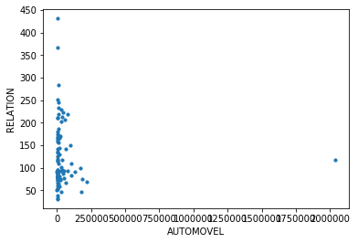

```python
df_frota_auto_bus.plot.scatter('AUTOMOVEL','RELATION',s=10);
```

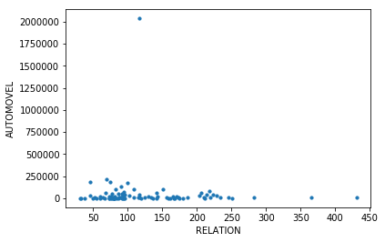

```python
df_frota_auto_bus.plot.scatter('RELATION','AUTOMOVEL',s=10);
```

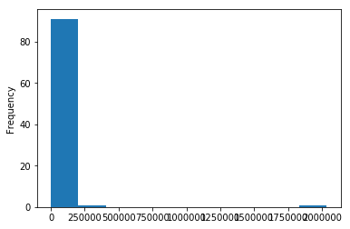

```python
df_frota_auto_bus.AUTOMOVEL.plot.hist();
```

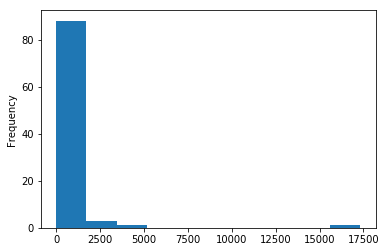

```python
df_frota_auto_bus.ONIBUS.plot.hist();
```

### O histograma abaixo apresenta a distribuição nos valores da relação entre total de automóveis pelo total de ônibus nas cidades do estado do Rio de Janeiro

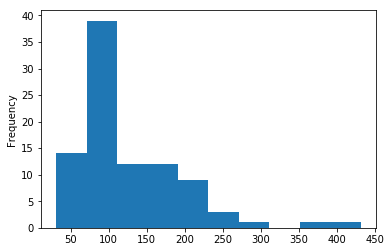

```python
df_frota_auto_bus.RELATION.plot.hist();
```

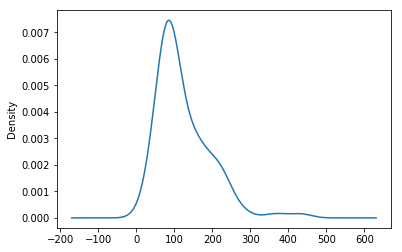

```python
df_frota_auto_bus.RELATION.plot.kde();
```

```python
df_frota_auto_bus.RELATION.var()
```

```
4956.981718209874
```

O calculo abaixo representa a medida do desvio padrão dos dados em relação à média amostral

```python
df_frota_auto_bus.RELATION.std()
```

```
70.40583582495043
```

```python
df_frota_auto_bus.RELATION.mean()
```

```
124.21223321282662
```

Calculo da correlacao entre automovel e onibus

```python
df_frota_auto_bus.AUTOMOVEL.corr(df_frota_auto_bus.ONIBUS) # correlacao linear positiva
```

```
0.986730526624075
```

```python
df_frota_auto_bus.corr() # correlacao entre os atributos do dataset
```

|  | AUTOMOVEL | ONIBUS | RELATION |
| --- | --- | --- | --- |
| AUTOMOVEL | 1.000000 | 0.986731 | -0.034309 |
| ONIBUS | 0.986731 | 1.000000 | -0.087405 |
| RELATION | -0.034309 | -0.087405 | 1.000000 |

```python
df_frota.corr() # correlacao entre todas as variaveis do problema
```

|  | TOTAL | AUTOMOVEL | BONDE | CAMINHAO | CAMINHAO TRATOR | CAMINHONETE | CAMIONETA | CHASSI PLATAF | CICLOMOTOR | MICRO-ONIBUS | ... | ONIBUS | QUADRICICLO | REBOQUE | SEMI-REBOQUE | SIDE-CAR | OUTROS | TRATOR ESTEI | TRATOR RODAS | TRICICLO | UTILITARIO |
| --- | --- | --- | --- | --- | --- | --- | --- | --- | --- | --- | --- | --- | --- | --- | --- | --- | --- | --- | --- | --- | --- |
| TOTAL | 1.000000 | 0.999782 | NaN | 0.983431 | 0.880901 | 0.998925 | 0.997728 | 0.959424 | 0.892514 | 0.997019 | ... | 0.987863 | 0.968038 | 0.965950 | 0.871247 | 0.761234 | 0.988744 | 0.013780 | 0.961550 | 0.984172 | 0.987858 |
| AUTOMOVEL | 0.999782 | 1.000000 | NaN | 0.980429 | 0.876227 | 0.998017 | 0.998562 | 0.961032 | 0.885207 | 0.997214 | ... | 0.986731 | 0.970715 | 0.961353 | 0.866014 | 0.752744 | 0.988549 | 0.006535 | 0.959359 | 0.983086 | 0.989399 |
| BONDE | NaN | NaN | NaN | NaN | NaN | NaN | NaN | NaN | NaN | NaN | ... | NaN | NaN | NaN | NaN | NaN | NaN | NaN | NaN | NaN | NaN |
| CAMINHAO | 0.983431 | 0.980429 | NaN | 1.000000 | 0.928396 | 0.988779 | 0.973291 | 0.932697 | 0.917480 | 0.975847 | ... | 0.983565 | 0.928706 | 0.976589 | 0.922303 | 0.780552 | 0.967547 | 0.035120 | 0.957078 | 0.982181 | 0.950626 |
| CAMINHAO TRATOR | 0.880901 | 0.876227 | NaN | 0.928396 | 1.000000 | 0.893997 | 0.865636 | 0.822539 | 0.839881 | 0.865601 | ... | 0.914151 | 0.811149 | 0.887537 | 0.995891 | 0.744069 | 0.861797 | 0.094953 | 0.900732 | 0.919550 | 0.834487 |
| CAMINHONETE | 0.998925 | 0.998017 | NaN | 0.988779 | 0.893997 | 1.000000 | 0.995257 | 0.957723 | 0.898299 | 0.994759 | ... | 0.987986 | 0.963372 | 0.971243 | 0.885035 | 0.771763 | 0.989359 | 0.029345 | 0.964930 | 0.985516 | 0.984199 |
| CAMIONETA | 0.997728 | 0.998562 | NaN | 0.973291 | 0.865636 | 0.995257 | 1.000000 | 0.965859 | 0.872524 | 0.996633 | ... | 0.980279 | 0.978122 | 0.951194 | 0.855758 | 0.741859 | 0.990121 | 0.006243 | 0.958292 | 0.979793 | 0.994504 |
| CHASSI PLATAF | 0.959424 | 0.961032 | NaN | 0.932697 | 0.822539 | 0.957723 | 0.965859 | 1.000000 | 0.817478 | 0.960674 | ... | 0.930503 | 0.975052 | 0.891290 | 0.810504 | 0.688962 | 0.963669 | -0.015879 | 0.914837 | 0.930937 | 0.961476 |
| CICLOMOTOR | 0.892514 | 0.885207 | NaN | 0.917480 | 0.839881 | 0.898299 | 0.872524 | 0.817478 | 1.000000 | 0.891022 | ... | 0.889597 | 0.815815 | 0.931139 | 0.837600 | 0.826396 | 0.866390 | 0.185470 | 0.910332 | 0.891451 | 0.845361 |
| MICRO-ONIBUS | 0.997019 | 0.997214 | NaN | 0.975847 | 0.865601 | 0.994759 | 0.996633 | 0.960674 | 0.891022 | 1.000000 | ... | 0.980549 | 0.972193 | 0.959931 | 0.855220 | 0.752438 | 0.983377 | 0.036296 | 0.963062 | 0.977190 | 0.988060 |
| MOTOCICLETA | 0.995886 | 0.994024 | NaN | 0.988397 | 0.885934 | 0.996736 | 0.988376 | 0.947219 | 0.917151 | 0.990931 | ... | 0.987837 | 0.950179 | 0.977535 | 0.877372 | 0.788328 | 0.982899 | 0.034940 | 0.959664 | 0.981500 | 0.974483 |
| MOTONETA | 0.981121 | 0.977609 | NaN | 0.980209 | 0.878696 | 0.983954 | 0.971673 | 0.925777 | 0.933410 | 0.976344 | ... | 0.969083 | 0.932294 | 0.988144 | 0.873643 | 0.819910 | 0.968595 | 0.047013 | 0.958822 | 0.966173 | 0.960801 |
| ONIBUS | 0.987863 | 0.986731 | NaN | 0.983565 | 0.914151 | 0.987986 | 0.980279 | 0.930503 | 0.889597 | 0.980549 | ... | 1.000000 | 0.935058 | 0.964890 | 0.909009 | 0.755860 | 0.972480 | 0.023981 | 0.953484 | 0.988850 | 0.963950 |
| QUADRICICLO | 0.968038 | 0.970715 | NaN | 0.928706 | 0.811149 | 0.963372 | 0.978122 | 0.975052 | 0.815815 | 0.972193 | ... | 0.935058 | 1.000000 | 0.898825 | 0.801787 | 0.696492 | 0.968915 | -0.013157 | 0.931560 | 0.939629 | 0.979410 |
| REBOQUE | 0.965950 | 0.961353 | NaN | 0.976589 | 0.887537 | 0.971243 | 0.951194 | 0.891290 | 0.931139 | 0.959931 | ... | 0.964890 | 0.898825 | 1.000000 | 0.885153 | 0.830198 | 0.951957 | 0.071118 | 0.946699 | 0.951529 | 0.937208 |
| SEMI-REBOQUE | 0.871247 | 0.866014 | NaN | 0.922303 | 0.995891 | 0.885035 | 0.855758 | 0.810504 | 0.837600 | 0.855220 | ... | 0.909009 | 0.801787 | 0.885153 | 1.000000 | 0.749594 | 0.854238 | 0.108025 | 0.897325 | 0.915901 | 0.825266 |
| SIDE-CAR | 0.761234 | 0.752744 | NaN | 0.780552 | 0.744069 | 0.771763 | 0.741859 | 0.688962 | 0.826396 | 0.752438 | ... | 0.755860 | 0.696492 | 0.830198 | 0.749594 | 1.000000 | 0.752794 | 0.184459 | 0.792459 | 0.752859 | 0.737058 |
| OUTROS | 0.988744 | 0.988549 | NaN | 0.967547 | 0.861797 | 0.989359 | 0.990121 | 0.963669 | 0.866390 | 0.983377 | ... | 0.972480 | 0.968915 | 0.951957 | 0.854238 | 0.752794 | 1.000000 | 0.014080 | 0.944800 | 0.969034 | 0.988984 |
| TRATOR ESTEI | 0.013780 | 0.006535 | NaN | 0.035120 | 0.094953 | 0.029345 | 0.006243 | -0.015879 | 0.185470 | 0.036296 | ... | 0.023981 | -0.013157 | 0.071118 | 0.108025 | 0.184459 | 0.014080 | 1.000000 | 0.216346 | 0.020034 | 0.014167 |
| TRATOR RODAS | 0.961550 | 0.959359 | NaN | 0.957078 | 0.900732 | 0.964930 | 0.958292 | 0.914837 | 0.910332 | 0.963062 | ... | 0.953484 | 0.931560 | 0.946699 | 0.897325 | 0.792459 | 0.944800 | 0.216346 | 1.000000 | 0.955885 | 0.949211 |
| TRICICLO | 0.984172 | 0.983086 | NaN | 0.982181 | 0.919550 | 0.985516 | 0.979793 | 0.930937 | 0.891451 | 0.977190 | ... | 0.988850 | 0.939629 | 0.951529 | 0.915901 | 0.752859 | 0.969034 | 0.020034 | 0.955885 | 1.000000 | 0.962945 |
| UTILITARIO | 0.987858 | 0.989399 | NaN | 0.950626 | 0.834487 | 0.984199 | 0.994504 | 0.961476 | 0.845361 | 0.988060 | ... | 0.963950 | 0.979410 | 0.937208 | 0.825266 | 0.737058 | 0.988984 | 0.014167 | 0.949211 | 0.962945 | 1.000000 |

22 rows × 22 columns